# 2016年美帝总统竞选捐款分析（纽约州）

### 前期准备

#### 数据集选择

完整数据载入耗时过长，目测并不利于后续分析，所以计划选择某州数据进行初步分析。经了解，选举人票数可以体现人口数多少，各州数据包大小基本也符合该趋势。从传统来看，民主党（希拉里）票仓体量较大的州：加州CA、纽约NY、伊利诺伊州IL，共和党（特朗普）：德州TX。经测试，加州数据载入大约需要1分钟，为保证高效，此次首选同样较有明确倾向性（民主党）的NY数据集。

#### 关于数据字典

缩写 |内容 |数据类型  
————————|————————|————————  
CMTE_ID |委员会ID|9位字母数字S  
CAND_ID |候选人ID|9位字母数字S  
CAND_NM |候选人姓名|String  
CONTBR_NM |捐款人姓名|String  
CONTBR_CITY|捐款人城市|String  
CONTBR_ST |捐款人州 |String  
CONTBR_ZIP |捐款人邮编|String  
CONTBR_EMPLOYER |捐款人公司|String  
CONTBR_OCCUPATION|捐款人职业|String  
CONTB_RECEIPT_AMT|捐款数 |Numeric  
CONTB_RECEIPT_DT |捐款日期 |Date  
RECEIPT_DESC |捐款备注 |String  
MEMO_CD |备忘标记 |X表示有备忘（事实并不准确）  
MEMO_TEXT |备忘内容 |标签内容S  
FORM_TP |类型 |X表示有备忘S  
FILE_NUM |文件编码 |唯一Numeric  
TRAN_ID |电子文件编码|S  
ELECTION_TP|捐款类型年份|代码见说明S

#### 捐款类型说明

P = Primary 初选 主要选代表，在六月结束  
G = General 普选  
O = Other  
C = Convention nation concention 7、8月，全国代表大会，确定本党候选人  
R = Runoff 决选  
S = Special（本身可能包括P，G，R三个阶段）  
E = Recount 重新计票阶段  
参考链接：https://www.fec.gov/help-candidates-and-committees/candidate-taking-receipts/contribution-limits/

##### 纽约数据集概况

```
## 'data.frame':    649460 obs. of  18 variables:
##  $ cmte_id          : Factor w/ 25 levels "C00458844","C00500587",..: 6 6 7 7 6 7 7 6 6 15 ...
##  $ cand_id          : Factor w/ 25 levels "P00003392","P20002671",..: 1 1 12 12 1 12 12 1 1 23 ...
##  $ cand_nm          : Factor w/ 25 levels "Bush, Jeb","Carson, Benjamin S.",..: 4 4 20 20 4 20 20 4 4 23 ...
##  $ contbr_nm        : Factor w/ 119407 levels " BLACKMORE, ANDI POTAMKIN",..: 52356 19422 54646 61896 8862 63027 63080 54730 55289 91553 ...
##  $ contbr_city      : Factor w/ 2327 levels ""," BROOKLYN",..: 1424 287 1424 269 1620 1406 1644 1424 595 1424 ...
##  $ contbr_st        : Factor w/ 1 level "NY": 1 1 1 1 1 1 1 1 1 1 ...
##  $ contbr_zip       : Factor w/ 69028 levels "","`1136","0",..: 7135 64432 5890 40174 58413 30757 49101 5353 62817 69028 ...
##  $ contbr_employer  : Factor w/ 39302 levels ""," ENGENDERHEALTH",..: 23091 30023 24570 24031 16445 24882 33393 30988 23091 16445 ...
##  $ contbr_occupation: Factor w/ 17219 levels ""," ADMINISTRATIVE ASSISTANT",..: 13288 1249 10332 16184 7896 15445 12064 16984 13288 7896 ...
##  $ contb_receipt_amt: num  100 67 50 15 100 ...
##  $ contb_receipt_dt : Factor w/ 697 levels "1-Apr-15","1-Apr-16",..: 137 367 622 577 71 599 599 229 656 22 ...
##  $ receipt_desc     : Factor w/ 27 levels ""," SEE REATTRIBUTION",..: 1 1 1 1 1 1 1 1 1 1 ...
##  $ memo_cd          : Factor w/ 2 levels "","X": 2 2 1 1 2 1 1 2 2 2 ...
##  $ memo_text        : Factor w/ 262 levels ""," SEE REATTRIBUTION",..: 33 33 5 5 33 5 5 33 33 1 ...
##  $ form_tp          : Factor w/ 3 levels "SA17A","SA18",..: 2 2 1 1 2 1 1 2 2 2 ...
##  $ file_num         : int  1091718 1091718 1077404 1077404 1091718 1077404 1077404 1091718 1091718 1146165 ...
##  $ tran_id          : Factor w/ 648415 levels "A00136D649BB94F13985",..: 275346 275731 533152 531094 275039 532242 531783 275424 274830 450800 ...
##  $ election_tp      : Factor w/ 6 levels "","G2016","O2016",..: 5 5 5 5 5 5 5 5 5 2 ...
```

纽约数据集中一共约65万条记录，涉及25名候选人，不包含候选人党派信息

##### 候选人情况分析

为保险起见，参考全国数据（744万+）选择最热门人选：  
Clinton, Hillary Rodham（民主党）350万+  
Sanders, Bernard桑德斯(登记民主党，自称民主社会党)206万+  
Trump, Donald J. 特朗普（共和党）78万  
Cruz, Rafael Edward ‘Ted’（共和党）5.4日退选，约55.8万  
Carson, Benjamin S.(共和党) 3月退选 约25万  
Rubio, Marco（共和党）古巴裔，3.15在佛罗里达州败给特朗普后退选，10万+  
Paul, Rand（共和党）2.3号退选，3.2万+  
Bush, Jeb（共和党）6.15号退选，约3万  
Fiorina, Carly（共和党），约2.8万  
以上覆盖了约98.8%的数据

##### 捐款者职业整理

64万条捐款数据对应1.7万种职业，略有些庞杂。起初考虑根据生活经验将一些职业类型合并，但是后期在分析的过程中发现在没有经过严密论证前贸然合并并不是个好选择，所以只合并数量较多的、显然相同的职业名：  
INFORMATION REQUESTED：INFORMATION REQUESTED PER BEST EFFORTS；  
SELF-EMPLOYED：SELF EMPLOYED, SELF；  
CEO：CHIEF EXECUTIVE OFFICER，C.E.O.；

```
##                  RETIRED             NOT EMPLOYED                 ATTORNEY
##                    98667                    47994                    26486
##    INFORMATION REQUESTED                  TEACHER                PROFESSOR
##                    18566                    15080                    11777
##                PHYSICIAN                   LAWYER               CONSULTANT
##                    10897                    10011                     8878
##                   WRITER                HOMEMAKER
##                     7937                     7689                     6266
##                   ARTIST                  STUDENT                    SALES
##                     5595                     5477                     4163
##                  MANAGER            SELF-EMPLOYED                 ENGINEER
##                     3758                     3745                     3593
##        SOFTWARE ENGINEER             PSYCHOLOGIST                 DESIGNER
##                     3544                     3500                     3390
##            SOCIAL WORKER                 MUSICIAN         REGISTERED NURSE
##                     3113                     3037                     2992
##                ARCHITECT                      CEO              REAL ESTATE
##                     2905                     2894                     2847
##                MARKETING                    ACTOR                EXECUTIVE
##                     2795                     2764                     2684
##                 EDUCATOR          PSYCHOTHERAPIST                   EDITOR
##                     2561                     2518                     2340
##                PRESIDENT                  FINANCE                    OWNER
##                     2265                     2069                     2008
##            ADMINISTRATOR               ACCOUNTANT             PHOTOGRAPHER
##                     2006                     1911                     1895
##                 DIRECTOR              ADVERTISING           BUSINESS OWNER
##                     1887                     1779                     1660
##       REAL ESTATE BROKER          PROJECT MANAGER                       RN
##                     1482                     1480                     1467
##        CREATIVE DIRECTOR           OFFICE MANAGER                FILMMAKER
##                     1427                     1413                     1403
##       SOFTWARE DEVELOPER                LIBRARIAN                   BANKER
##                     1388                     1355                     1323
##                SCIENTIST                  ANALYST                 PRODUCER
##                     1315                     1288                     1264
##       EXECUTIVE DIRECTOR           VICE PRESIDENT         PUBLIC RELATIONS
##                     1259                     1238                     1187
##      EXECUTIVE ASSISTANT             PSYCHIATRIST ADMINISTRATIVE ASSISTANT
##                     1144                     1106                     1055
```

[output cut: 13 more lines]

```
##                      754                      751                      732
##           COMMUNICATIONS                PARALEGAL                EDUCATION
##                      722                      722                      720
##                   RETAIL                      N/A          RETIRED TEACHER
##                      719                      710                      709
##        ADJUNCT PROFESSOR               BOOKKEEPER                       MD
##                      706                      701                      694
##                  ACTRESS               PHARMACIST                PRINCIPAL
##                      693                      693                      686
##                     CHEF     SMALL BUSINESS OWNER        REAL ESTATE AGENT
##                      681                      670                      649
##               CONTRACTOR                  DENTIST                  (Other)
##                      638                      637                   238093
##                     NA's
##                       78
```

这项属性似乎是由捐款人自主填写，相同的职业会有重复出现，同时夹杂了大量的类似职业。除非花大力气整理捐款人职业这一栏，似乎很难精确分析出职业的和捐款情况之间的关系。

##### 候选人党派信息

当前数据不包括候选人所属党派信息，根据候选人情况分析部分的功课，添加候选人党派信息：Republican or Democrat  
因为已列出党派的人员已经涵盖了98%+的捐款记录，所以此次分析排除无党派信息的人员捐款情况

```
##              Democrat Republican
##       5412     574086      69962
```

### 单变量图像

##### 捐款数分析

```
##     Min.  1st Qu.   Median     Mean  3rd Qu.     Max.
##   -10100       15       27      264      100 12777706
```

```
##    Mode   FALSE    TRUE
## logical    8530  640930
```

统计捐款数发现，数据集中还有8K5+条捐款为负的记录，经查证该部分数据值为退款情况，在此次分析中排除这类数据。

```
##     Min.  1st Qu.   Median     Mean  3rd Qu.     Max.
##        0       15       27      269      100 12777706
```

```
##    Mode   FALSE    TRUE
## logical  635652      30
```

去掉退款部分数据后，观察发现：最高捐款金额已经超过1千万，但从均值来看为269刀，75%的捐款不超过100刀，推测超大额捐款记录并不多。统计后发现，在63.5万条记录中，只有30笔捐款超过1万刀。

```
##  99%
## 2700
```

```
## 95%
## 500
```

99%的捐款数额在2700刀以下，95%的捐款数额在500刀以下

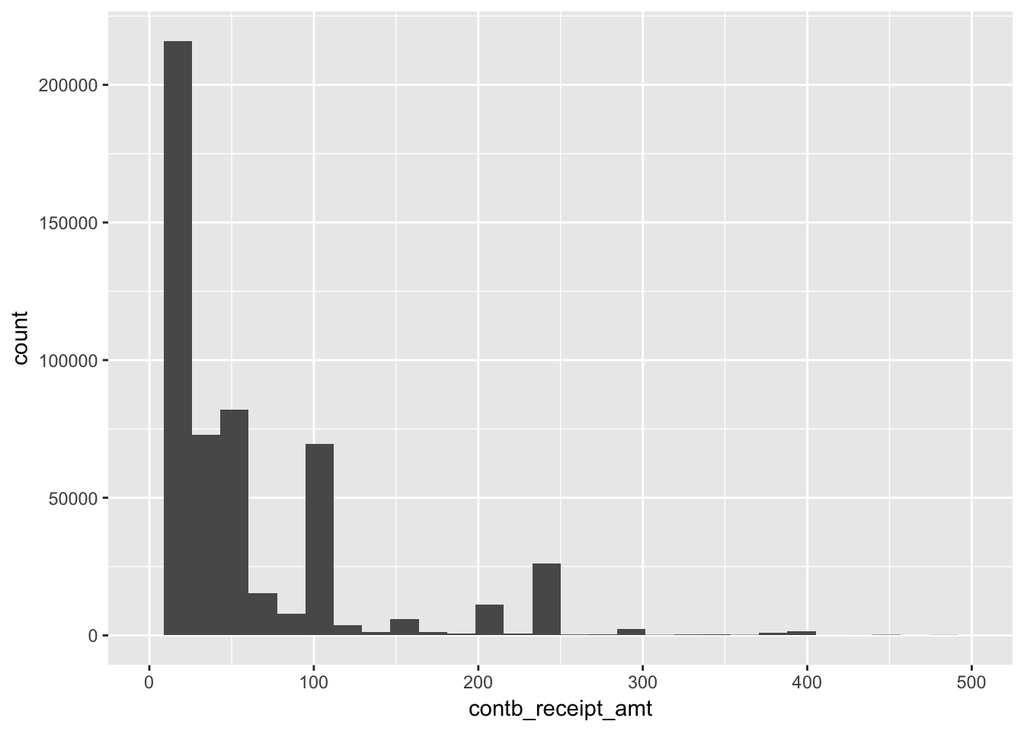

从直方图来看，捐款主要集中在100刀以下，少于50刀的更明显些。考虑通过坐标轴变换的方式再进行观察

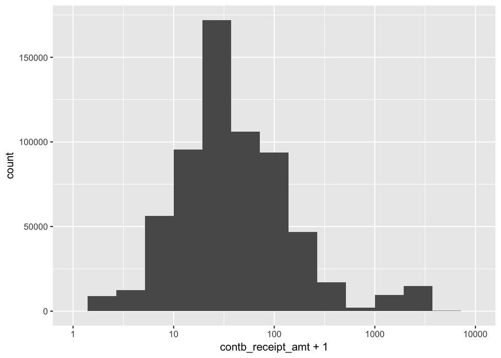

通过对上一个图像进行对数变换，发现捐款主要集中在10~100刀这个区间。为进一步观察，考虑放大这一区间，并合理猜测在若干整数点的位置有可能会出现集中（人们可能偏爱捐10、25、50这样较为整的数）

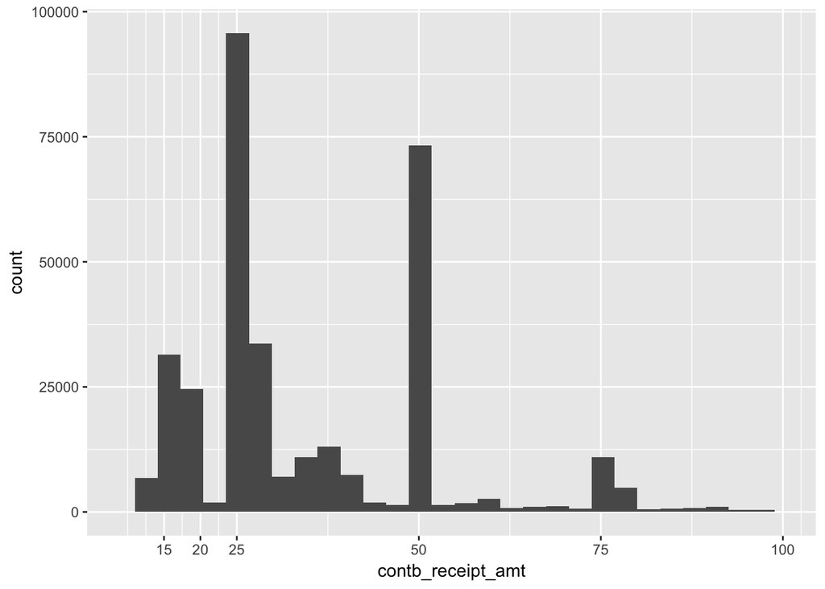

如之前猜测，捐款多数集中在10刀~100刀,且这期间密级集中在：15刀，20刀，25刀，50刀，75刀这几个数字上

##### 两党获得的捐款笔数

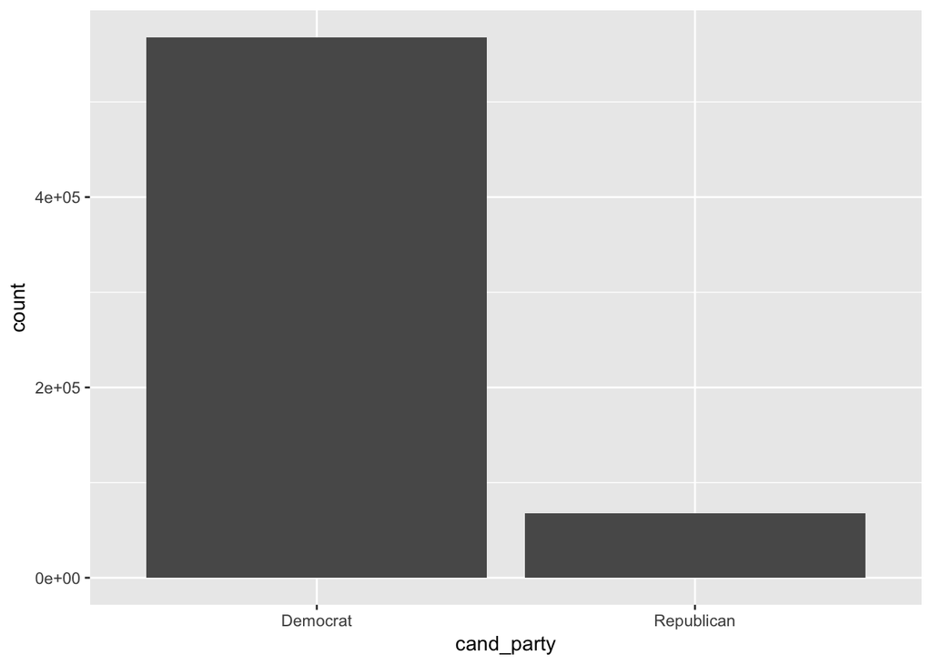

民主党捐款记录有57w+条，共和党只有不到7万条。

##### 各候选人获得捐款笔数

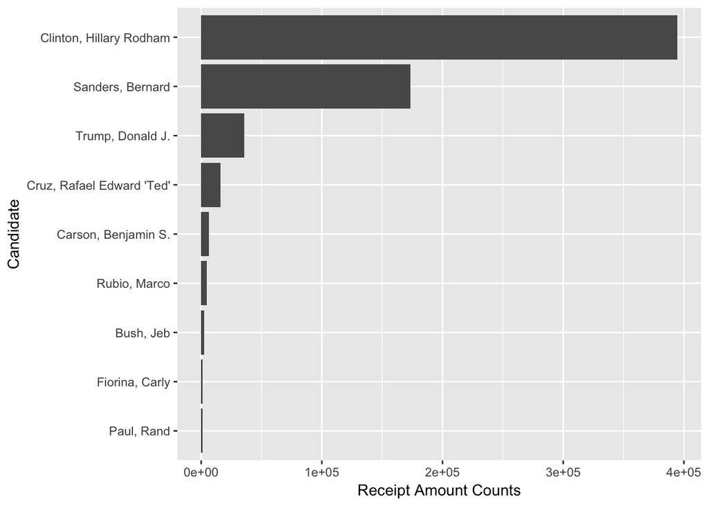

希拉里获得近40万笔捐款，桑德斯次之获得17.3万+笔，最终获胜者特朗普仅获得不到3.6万笔捐款。

##### 捐款来源地区分析

```
##           NEW YORK           BROOKLYN              BRONX
##             201856              85707              13856
##          ROCHESTER      STATEN ISLAND            BUFFALO
##               9723               7269               6055
##             ITHACA            ASTORIA             ALBANY
##               5782               5178               5139
##           SYRACUSE       WHITE PLAINS          SCARSDALE
##               3883               3593               3549
##       NEW ROCHELLE       FOREST HILLS   LONG ISLAND CITY
##               3197               3081               2942
##        SCHENECTADY            YONKERS          LARCHMONT
##               2701               2653               2517
##          CHAPPAQUA           FLUSHING       POUGHKEEPSIE
##               2169               2112               2061
##   SARATOGA SPRINGS         BRONXVILLE         GREAT NECK
##               2047               1989               1981
##            JAMAICA           WOODSIDE               TROY
##               1856               1804               1739
##           OSSINING              NYACK    JACKSON HEIGHTS
##               1725               1685               1642
##          PITTSFORD    PORT WASHINGTON           KINGSTON
##               1630               1599               1589
##       EAST HAMPTON HASTINGS ON HUDSON         LONG BEACH
##               1583               1578               1573
##         HUNTINGTON        MOUNT KISCO                RYE
##               1565               1491               1450
##             DELMAR         BINGHAMTON          TARRYTOWN
##               1435               1408               1403
##         SAG HARBOR        DOBBS FERRY            BAYSIDE
##               1270               1257               1220
##          NEW PALTZ        PLATTSBURGH          RIDGEWOOD
##               1199               1199               1199
##   CROTON ON HUDSON          REGO PARK          DIX HILLS
##               1193               1165               1163
##        STONY BROOK         MAMARONECK       MOUNT VERNON
##               1153               1143               1135
##          SUNNYSIDE            KATONAH           NEW CITY
##               1133               1088               1067
##             PELHAM          HARTSDALE   YORKTOWN HEIGHTS
##               1042               1035               1034
```

[output cut: 13 more lines]

```
##                865                864                858
##          IRVINGTON      WILLIAMSVILLE          WOODSTOCK
##                857                855                845
##        COLD SPRING            HAMBURG         MIDDLETOWN
##                836                836                834
##         QUEENSBURY             BEACON   BRIARCLIFF MANOR
##                823                820                814
## HUNTINGTON STATION   ROCKVILLE CENTRE            SYOSSET
##                807                797                795
##     EAST NORTHPORT             LATHAM        SOUTHAMPTON
##                786                775                764
##           NEWBURGH        FLORAL PARK           FREEPORT
##                762                746                745
##            (Other)
##             171428
```

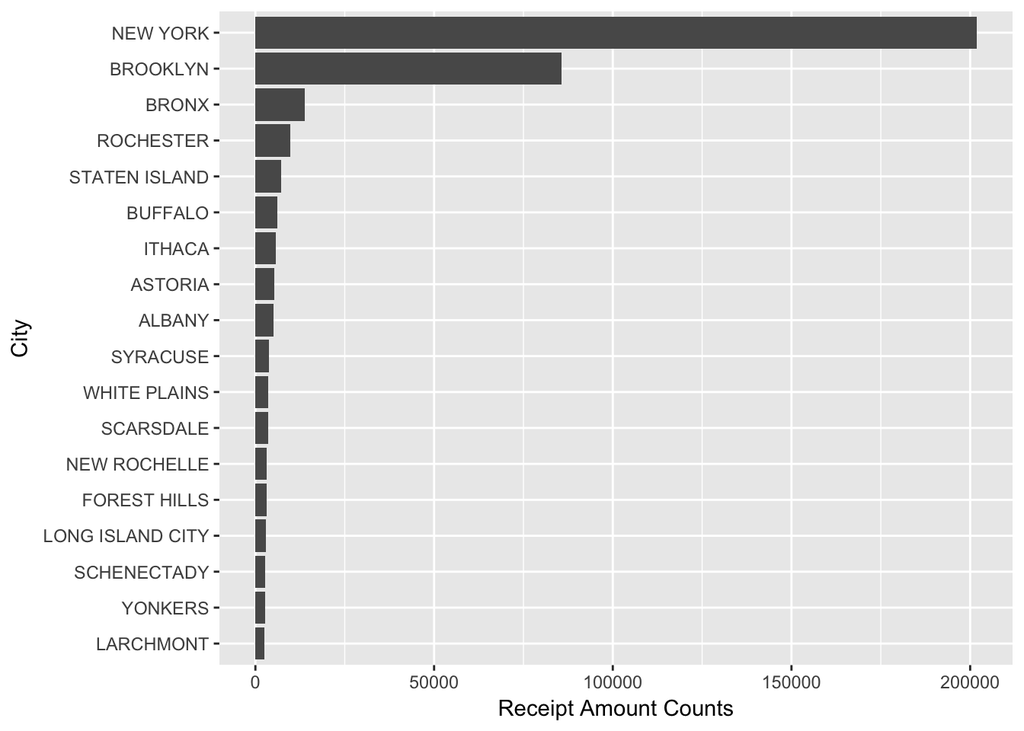

经查，纽约州主要城市：New York City, Buffalo, Rochester, Yonkers, Syracuse, Albany(州首府)。 纽约市主要县：New York(曼哈顿), Brooklyn, Bronx, Staten Island, Queens  
这与捐款集中的地区是基本吻合的。

##### 捐款人职业分析

```
##                  RETIRED             NOT EMPLOYED                 ATTORNEY
##                    97090                    47965                    26071
##    INFORMATION REQUESTED                  TEACHER                PROFESSOR
##                    18365                    15002                    11714
##                PHYSICIAN                   LAWYER               CONSULTANT
##                    10764                     9874                     8786
##                   WRITER                HOMEMAKER                   ARTIST
##                     7875                     7493                     5566
##                  STUDENT                    SALES                  MANAGER
##                     5428                     4106                     3712
##            SELF-EMPLOYED                 ENGINEER        SOFTWARE ENGINEER
##                     3672                     3545                     3504
##             PSYCHOLOGIST                 DESIGNER            SOCIAL WORKER
##                     3491                     3384                     3106
##                 MUSICIAN         REGISTERED NURSE                ARCHITECT
##                     3032                     2989                     2889
##                MARKETING                      CEO                    ACTOR
##                     2791                     2765                     2760
##              REAL ESTATE                EXECUTIVE                 EDUCATOR
##                     2751                     2594                     2544
##          PSYCHOTHERAPIST                   EDITOR                PRESIDENT
##                     2516                     2334                     2199
##            ADMINISTRATOR                  FINANCE                    OWNER
##                     2002                     2000                     1955
##             PHOTOGRAPHER               ACCOUNTANT                 DIRECTOR
##                     1890                     1875                     1873
##              ADVERTISING           BUSINESS OWNER          PROJECT MANAGER
##                     1773                     1628                     1466
##       REAL ESTATE BROKER                       RN        CREATIVE DIRECTOR
##                     1466                     1461                     1424
##           OFFICE MANAGER                FILMMAKER       SOFTWARE DEVELOPER
##                     1405                     1396                     1380
##                LIBRARIAN                SCIENTIST                  ANALYST
##                     1354                     1307                     1274
##       EXECUTIVE DIRECTOR                 PRODUCER                   BANKER
##                     1250                     1250                     1249
##           VICE PRESIDENT         PUBLIC RELATIONS      EXECUTIVE ASSISTANT
##                     1230                     1176                     1138
## ADMINISTRATIVE ASSISTANT             PSYCHIATRIST         GRAPHIC DESIGNER
##                     1055                     1038                     1030
```

[output cut: 13 more lines]

```
##                      721                      716                      715
##                   RETAIL                 INVESTOR                EDUCATION
##                      714                      712                      705
##          RETIRED TEACHER        ADJUNCT PROFESSOR               BOOKKEEPER
##                      705                      703                      699
##                  ACTRESS               PHARMACIST                       MD
##                      692                      688                      687
##                     CHEF                      N/A                PRINCIPAL
##                      680                      678                      671
##     SMALL BUSINESS OWNER        REAL ESTATE AGENT               JOURNALIST
##                      666                      648                      632
##                  DENTIST        INTERIOR DESIGNER                  (Other)
##                      623                      612                   234700
##                     NA's
##                       66
```

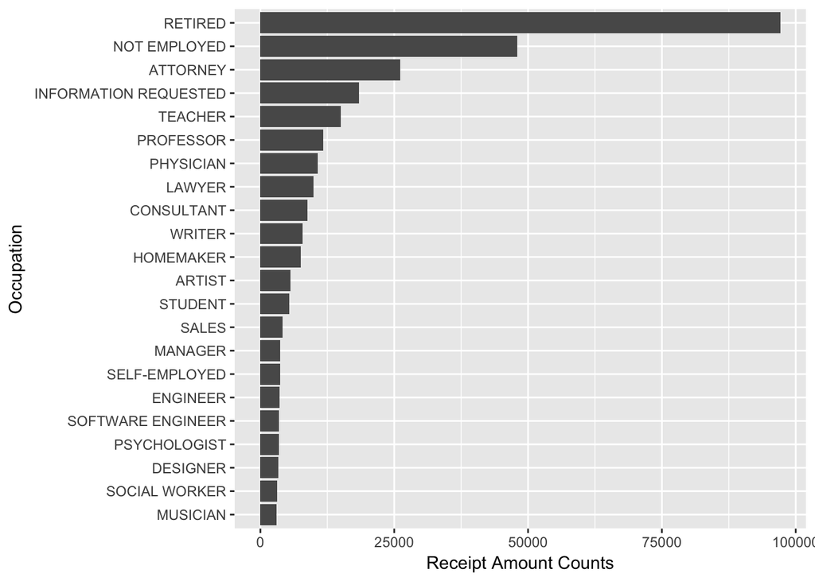

图中展现了捐款人职业的分布情况，退休人士体现出来了强烈的捐款意愿，非雇佣状态的人紧随其后，由此猜测所谓的Not employed很可能并不完全是一般概念下生活失意的失业人士（真·失业人士怎么会有闲钱捐款给总统竞选啊）

##### 捐款集中的时间阶段

```
##         G2016  O2016  P2015  P2016  P2020
##    568 265794      0      1 369319      0
```

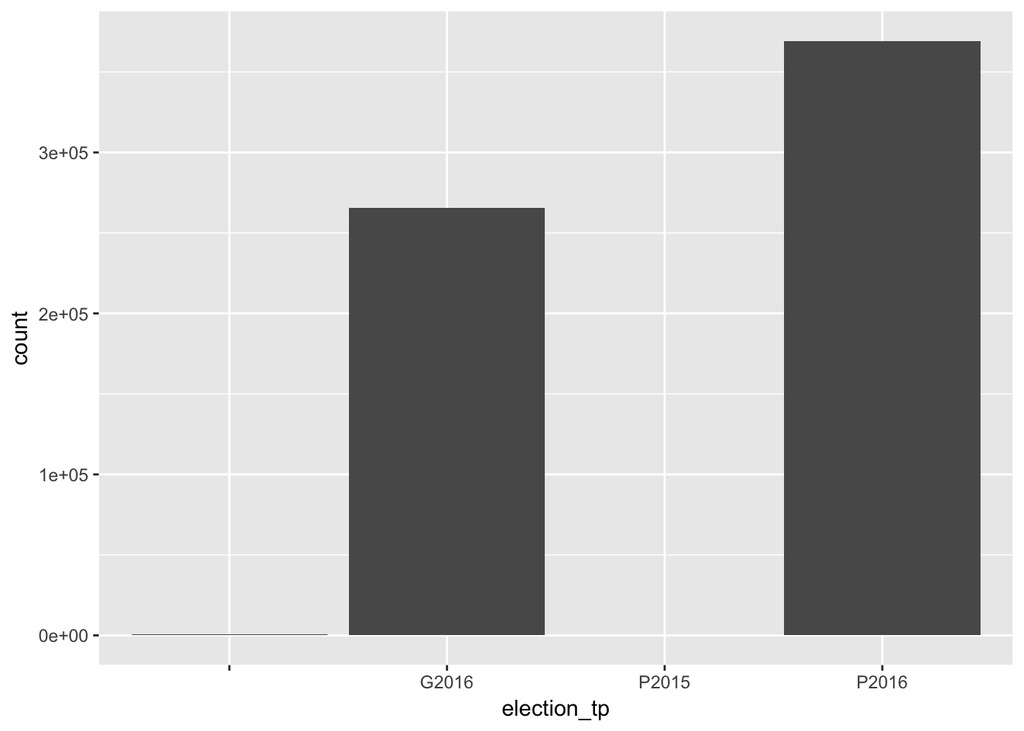

在63.5万条记录中，约37万条捐款集中在初选阶段，26.5万条记录集中在普选阶段。捐款看起来是持续在整个竞选过程之中的。  
其中P2015的记录猜测有可能是填写错误造成的，还有568条记录未填写时间段，原因未知

### 单变量分析

##### 数据集分析概况

单变量观察结果：  
- 纽约州明显倾向于民主党：民主党捐款记录有57w+条，共和党只有不到7万条；  
- 捐款较为活跃的城市与纽约州的主要城市列表基本吻合，严格来讲，纽约州的主要捐款还是集中在纽约市的主要几个区；  
- 捐款人职业粒度较小，且有相同职业的不同填写方式，并不利于聚类分析；  
- 捐款额的中位数为27，75%的捐款小于100美元，95%的捐款小于500美元，最高捐款额为12777705.6美元 - 捐款集中在初选和普选两段时间内：约37万条捐款产生在初选阶段，26.5万条记录产生在普选阶段；

##### 本数据集分析的核心

总统竞选捐款情况的核心数据应该是捐款额，候选人所属党派和候选人，三者依次递减。理想的效果是能根据捐款情况分析每个州的党派倾向、候选人倾向，结合美国总统大选的制度，预测出最终的优胜者。

##### 是否在数据集中加入了新变量

是的，根据美国总统选举制度，每个党派各选出一名候选人后，总统竞选才算正式开始。党派信息是很重要的一个属性值。后续可以按党派分析不同州、不同职业的党派倾向。

##### 目前为止发现哪些不寻常的数据情况

仅有30笔捐款超过1万刀，按金额排序，前23名几乎全部超过10w刀（最小一笔为9.74w），最大一笔超过千万级，且这23大额捐款全部来自于希拉里某基金会捐向希拉里。其它7笔捐款均不超过1.1w刀。后期分析在计算某些均值时，需要酌情考虑排除这23笔捐款的影响。事实上我并没有想清楚是否应该排除这些数据，一方面他们可能严重影响涉及平均值的分析，另一方面这说明希拉里的团队非常非常非常有钱（虽然最后希拉里并未获胜），不能忽视这一因素对竞选的影响。

##### 在下一阶段可以从尝试哪些方面分析数据集

- 不同地区和捐款情况之间的关系
- 不同职业和捐款之间的关系
- 不同地区对党派的倾向
- 不同候选人获得捐款的情况
- 普选阶段（G2016）是不是只有希拉里和特朗普了（我对选举制度实在不很了解）
- 不同职业对党派的倾向
- ……

### 双变量图像

##### 地区与捐款的关系

```
##     Min.  1st Qu.   Median     Mean  3rd Qu.     Max.
##      1.0      2.0     18.5    277.6     97.0 201856.0
```

```
##    Mode   FALSE    TRUE
## logical    2262      28
```

纽约州2290个区县，有75%的区县捐款笔数不足100，不知道是因为地区填得过于随意，还是大多数人就是没什么兴趣捐款 捐款笔数超过100且均值超过250刀（全纽约州捐款均值为264刀）的地区共有28个

Lawrence、Rands Point、Bedford Corners这几个地区捐款数并不很出众，但均值极高，猜测应该都是富人区。

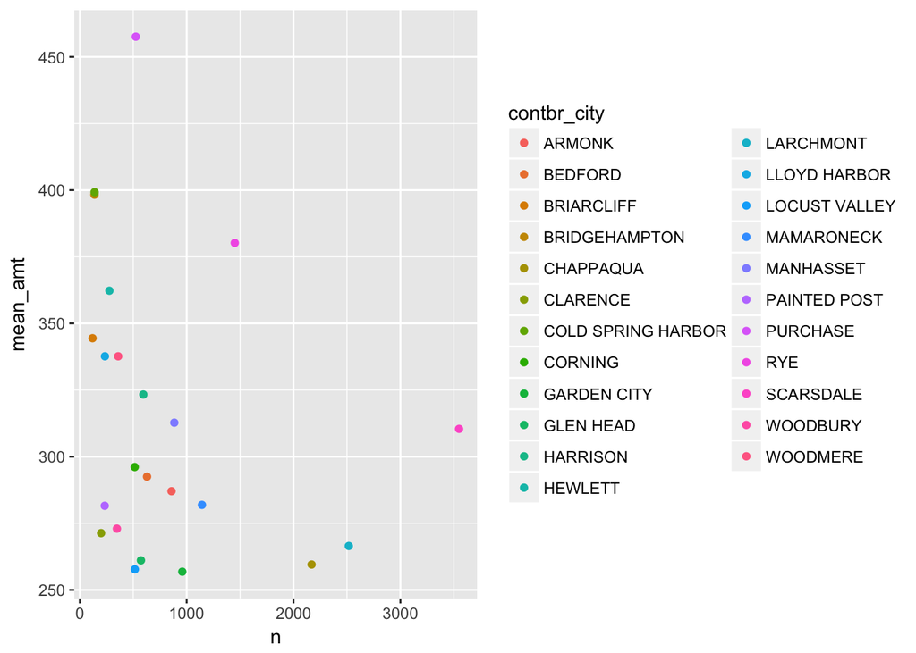

图上展示出了纽约州捐款数较多且均值较高的区域

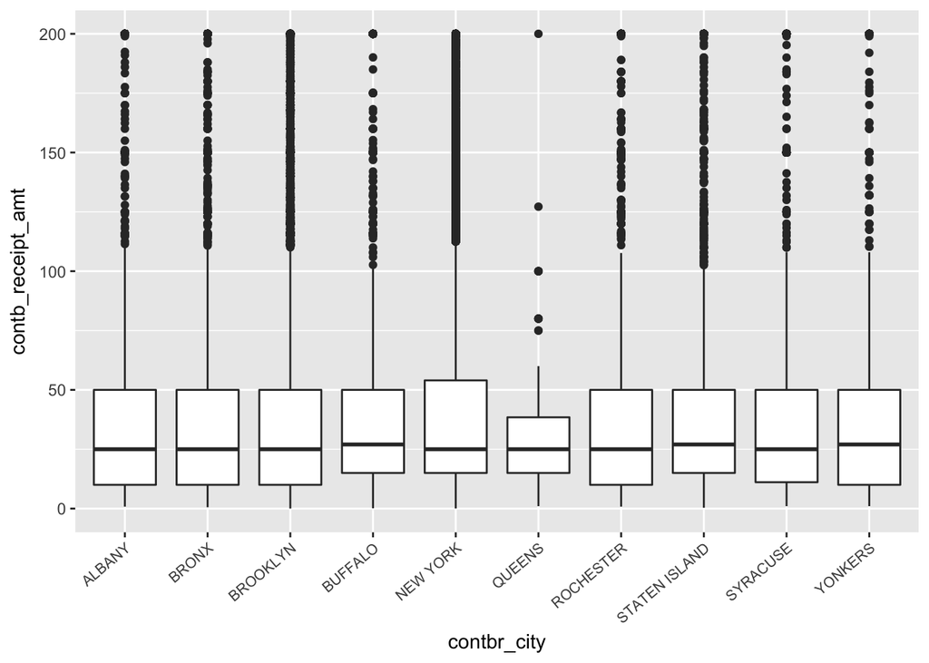

New York区是实打实的、毫无争议的人多又有钱。

从捐款箱线图上来看，纽约（曼哈顿区）和布鲁克林区大额捐款更多些，其它各区情况都差不多，中位数普遍持平，只有皇后区大额捐款数明显要少一些。

##### 职业和捐款之间的关系

```
##     Min.  1st Qu.   Median     Mean  3rd Qu.     Max.
##     1.00     1.00     3.00    37.76    10.00 97090.00
```

```
##    Mode   FALSE    TRUE
## logical   16303     529
```

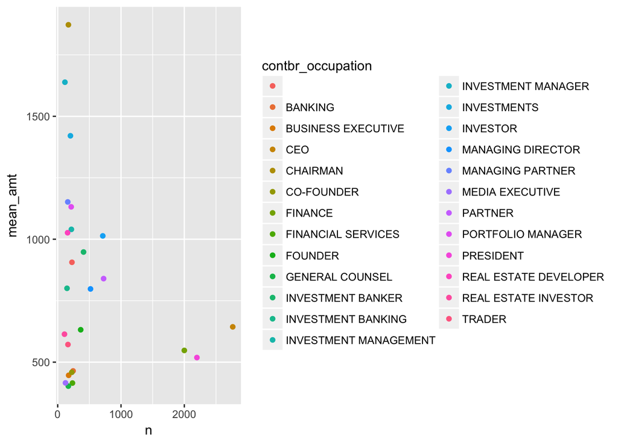

上图展示了捐款记录超过100条，人均超过400刀的职业，放眼望去和以下几个关键词密切相关：高管，金融，咨询，投资，银行……

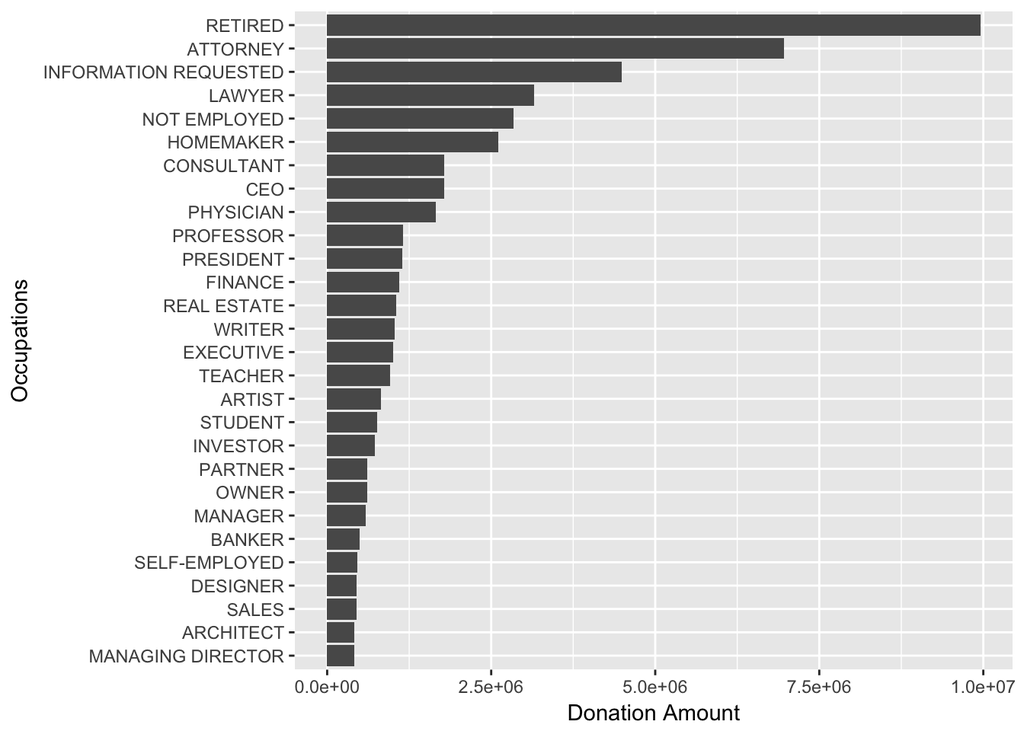

上图展示了纽约州捐款总量超过40万的职业

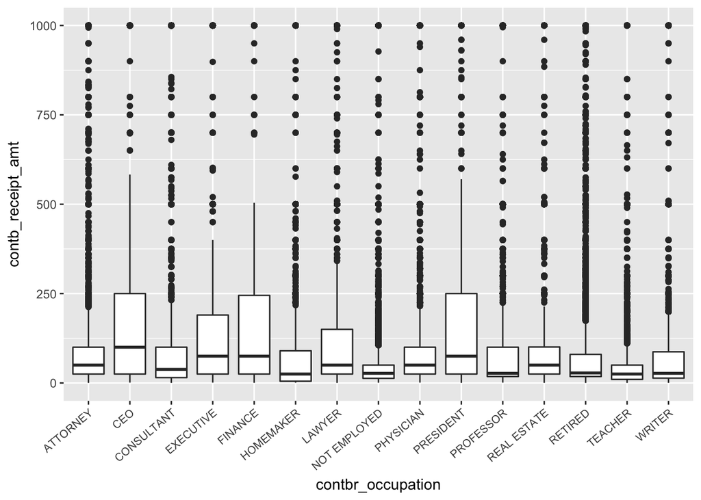

通过对职业与捐款情况的分析，初步可以看出以下结论:  
- 希拉里基金会的若干条大额捐款显著拉高了职业空白的平均数据（以平均32万刀遥遥领先）;  
- 退休人士的捐款积极性无与伦比（近10万条记录），捐款总金额也是最多的；  
- 律师行业的捐款总额如果相加的话，实际上要比退休人士更壮观；  
- 无业人士是个很有意思的形容，无业并不意味着没有闲钱捐款（近5万条记录），也许无业包括了相当多的自由职业；  
- 不同职业捐款分布的区分度比地区的区分度要更大；  
- Attorney的有钱程度似乎比Lawyer还是差一点儿，没搞明白这两者区别；

##### 候选人获得捐款的情况

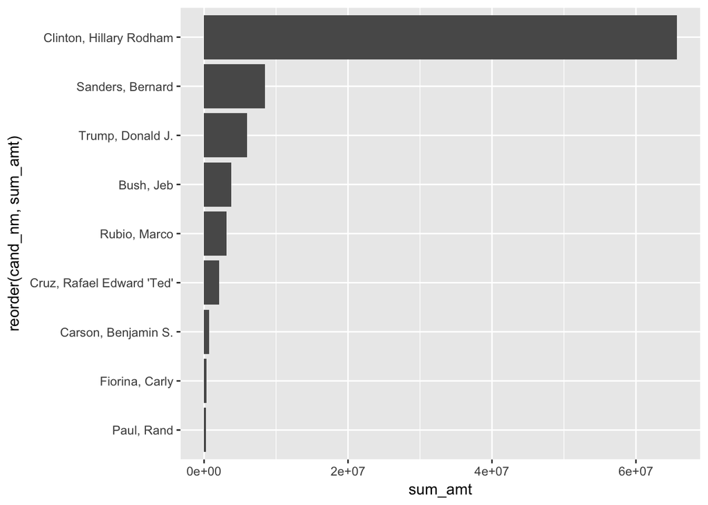

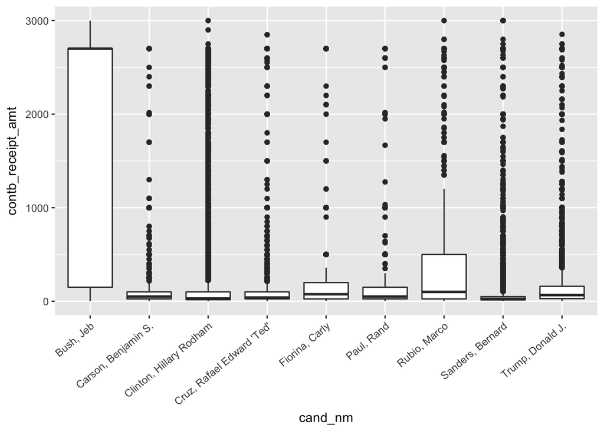

希拉里基金会捐赠的23笔大额捐款实在是过于Bug，所以在统计候选人获得捐款情况时，拿掉了这些记录。  
从结果来看，即使去掉了最大额的23笔捐款，与希拉里收获得盆满钵满相比，其他候选人的捐款情况要惨淡得多，呈现出数量级的差异。  
从箱线图来看，希拉里获得的捐款笔数多，但是捐款中位数反倒是候选者里相对较低的一位。Jeb·Bush反倒是获得了相当多金额较大的捐款，中位数在候选人里一骑绝尘。

##### 各候选人获得捐款分布的阶段

```
## subset_NY$election_tp:
##                 Bush, Jeb       Carson, Benjamin S.
##                         0                         0
##  Christie, Christopher J.   Clinton, Hillary Rodham
##                         0                        23
## Cruz, Rafael Edward 'Ted'            Fiorina, Carly
##                         0                         0
##      Gilmore, James S III        Graham, Lindsey O.
##                         0                         0
##            Huckabee, Mike             Jindal, Bobby
##                         0                         0
##             Johnson, Gary           Kasich, John R.
##                         0                         0
##          Lessig, Lawrence            McMullin, Evan
##                         0                         0
##   O'Malley, Martin Joseph         Pataki, George E.
##                         0                         0
##                Paul, Rand    Perry, James R. (Rick)
##                         0                         0
##              Rubio, Marco          Sanders, Bernard
##                         0                         0
##      Santorum, Richard J.               Stein, Jill
##                         0                         0
##          Trump, Donald J.             Walker, Scott
##                       545                         0
##     Webb, James Henry Jr.
##                         0
## --------------------------------------------------------
## subset_NY$election_tp: G2016
##                 Bush, Jeb       Carson, Benjamin S.
##                        34                        19
##  Christie, Christopher J.   Clinton, Hillary Rodham
##                         0                    247340
## Cruz, Rafael Edward 'Ted'            Fiorina, Carly
##                       223                         0
##      Gilmore, James S III        Graham, Lindsey O.
##                         0                         0
##            Huckabee, Mike             Jindal, Bobby
##                         0                         0
##             Johnson, Gary           Kasich, John R.
```

[output cut: 62 more lines]

```
##   O'Malley, Martin Joseph         Pataki, George E.
##                         0                         0
##                Paul, Rand    Perry, James R. (Rick)
##                      1117                         0
##              Rubio, Marco          Sanders, Bernard
##                      4366                    173386
##      Santorum, Richard J.               Stein, Jill
##                         0                         0
##          Trump, Donald J.             Walker, Scott
##                     17173                         0
##     Webb, James Henry Jr.
##                         0
## --------------------------------------------------------
## subset_NY$election_tp: P2020
## NULL
```

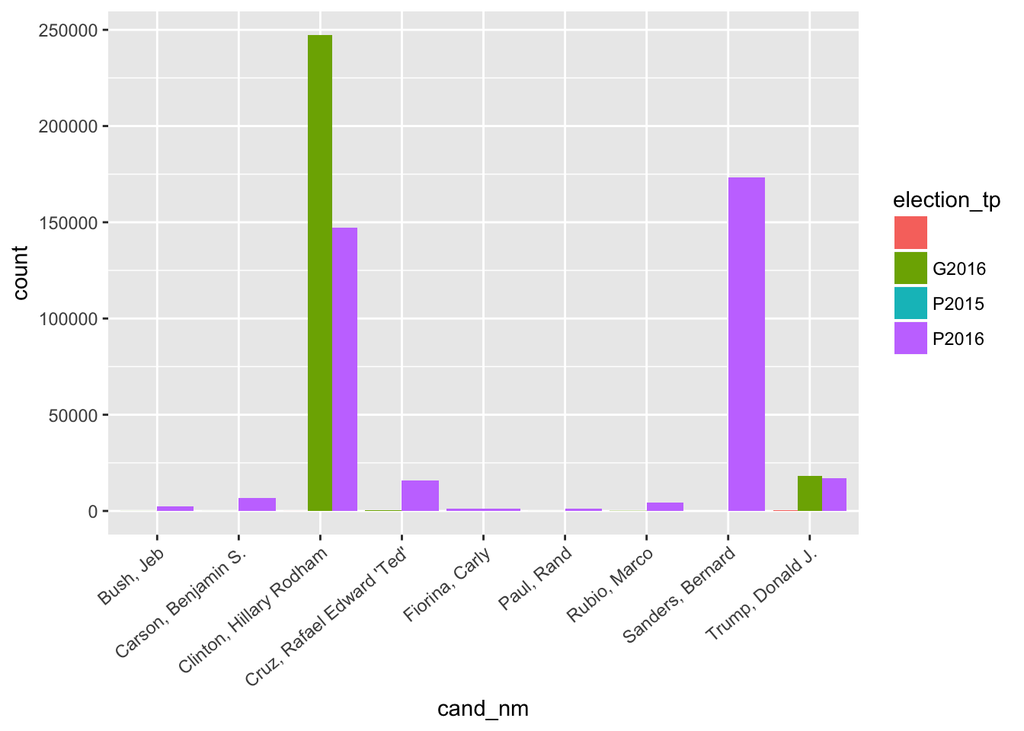

捐款整体集中在P2016（初选）G2016（普选）阶段，但并不是之前预想的在G普选阶段绝对只有希拉里和特朗普获得捐款，零星还有其它候选人获得了若干笔捐款款项。桑德斯获得的捐款确实仅集中在初选阶段。  
特朗普在两个阶段获得的捐款数基本持平，而希拉里在普选阶段获得了比初选阶段多更多的捐款。

##### 各党派获得捐款情况

```
## subset_NY$cand_party:
## NULL
## --------------------------------------------------------
## subset_NY$cand_party: Democrat
##     Min.  1st Qu.   Median     Mean  3rd Qu.     Max.
##        0       15       27      272       87 12777706
## --------------------------------------------------------
## subset_NY$cand_party: Republican
##    Min. 1st Qu.  Median    Mean 3rd Qu.    Max.
##     0.8    25.0    50.0   240.7   120.0 10800.0
```

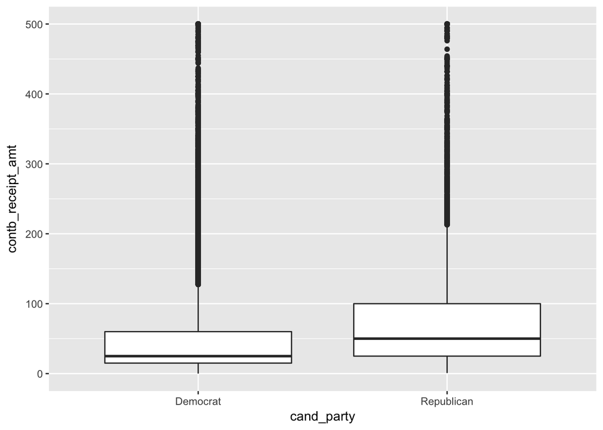

共和党获得的捐款金额从分布上看比民主党要更高一点。

### 双变量分析

在这部分调查中观察到的比较明显的趋势： - 捐款积极的地区非常明显地与纽约州中重点的城市、县郡重叠，各地区间捐款数值分布情况并没有太大差异，中位数普遍持平；  
- 退休人士、律师的捐款积极性极高，各职业捐款分布趋势差异较大，高薪职业的大额捐款相对较多，中位数参差不齐；  
- Jeb.Bush在所有候选人中，他获得的捐款明显数额高于其他人。希拉里获得的笔数、总额都远超于其他候选人，但她获得捐款金额普遍并不偏高；  
- 普选阶段的捐款基本集中在希拉里和特朗普两个人身上，希拉里在普选阶段获得了比初选阶段更多的捐款，特朗普在两个阶段内相对持平；  
- 共和党获得的捐款从中位数来看，比民主党反倒更高一些；

### 多变量图像

##### 职业对党派的倾向

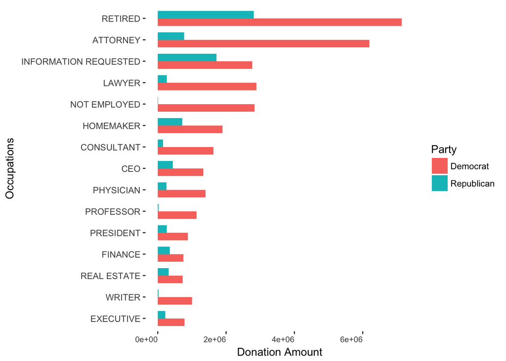

在纽约州，看起来大部分职业对共和党的捐款数都远不如对民主党的捐款数。

##### 民主党两大候选人获得捐款分析

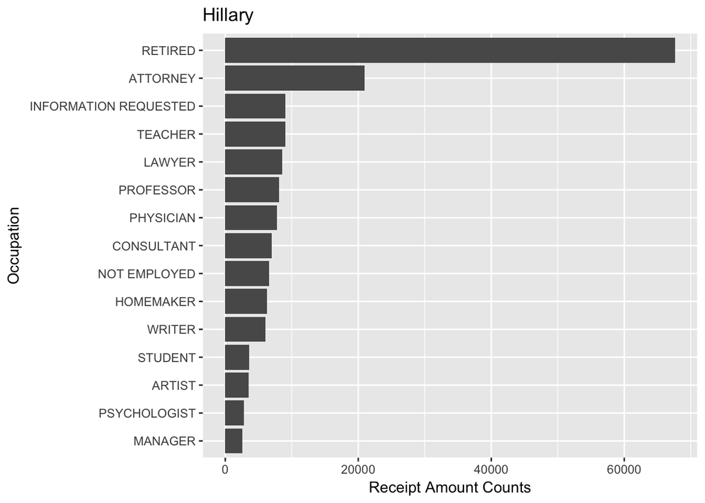

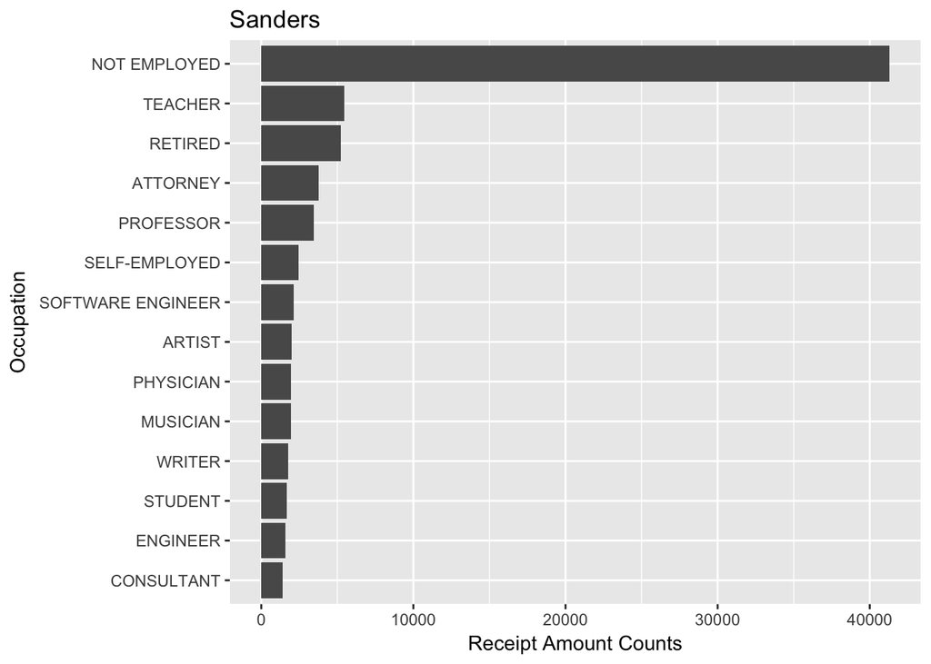

希拉里的主要支持者分布和总体数据集类似，但是桑德斯的捐款第一大来源是“无业人士”，且捐款笔数远高于其他职业，这很有意思。

##### 捐款人、党派获得捐款额分布

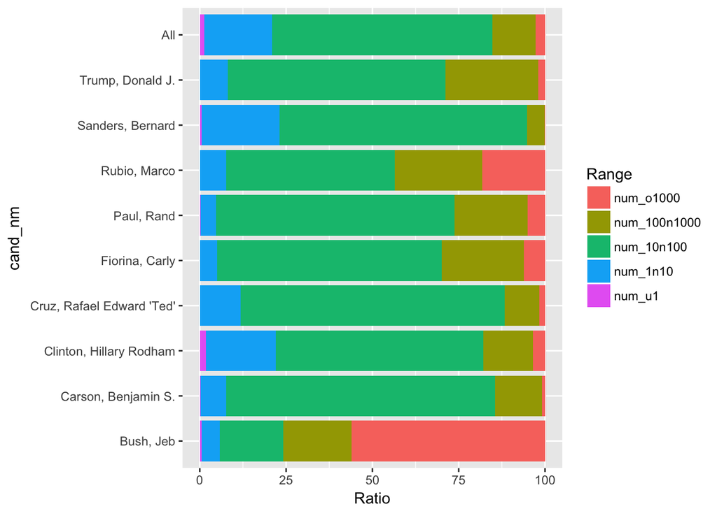

不同候选人获得的捐款组成略有差异。其中要考虑到希拉里获得的捐款比例过大，导致整体趋势和希拉里获得的捐款比例很相近。即使这样还是能看出：希拉里获得的1刀以下捐款的比例多于其它候选人；桑德斯最平民，几乎全部集中在100刀以下；Jeb.Bush最不平民，获得的数捐款都超过了1000刀。

##### 主要候选人获得捐款随时间变化趋势

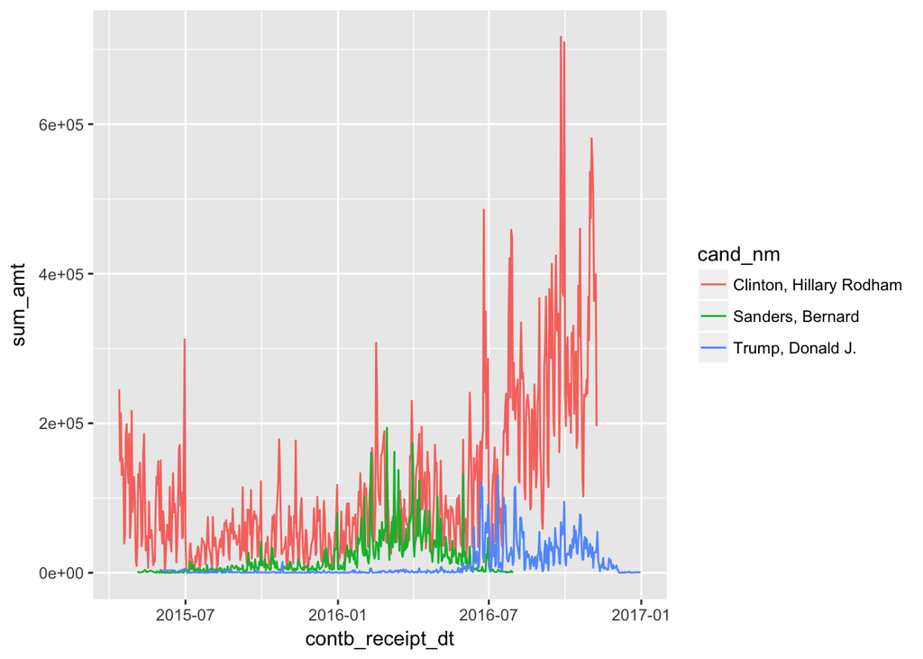

从图中可以看出候选人兴起和在竞选中退场的时间点。希拉里起步极早；桑德斯一度和希拉里在竞选资金获得的情况来看不相上下，但在惜败后退出；特朗普在党内胜出之前仿佛没什么市场。

### 多变量分析

- 纽约州全民偏向民主党多于共和党，从这里的数据看不太出来什么职业更偏向支持共和党一方；
- 同为民主党的候选人，希拉里和桑德斯的支持者组成差异还是较大的。希拉里的候选人群职业与总体数据相似，桑德斯的第一大支持人群是“无业人士”，这是比较特别的一点；
- 希拉里相比其他候选人并不完全是高收入人群支持比例较多，从比例上讲反倒略逊于部分候选人，她获得的捐款总量之多确实是得益于热度高，获得的笔数多。从这点上来看，桑德斯是实打实的平民支持，小额捐款比例明显高于其他候选人；Jeb.Bush表现得仿佛被大笔砸钱来玩票得富家子弟（似乎确实如此）。
- 主要捐款人获得的捐款趋势基本吻合候选人一路走来的热度变化趋势；

### 最终成图和汇总

##### 图像一

[figure not shown]

结论：在纽约州，全民偏向民主党。即使是共和党的主力贡献捐款人群，无一例外地贡献了更多的捐款给民主党。

##### 图像二

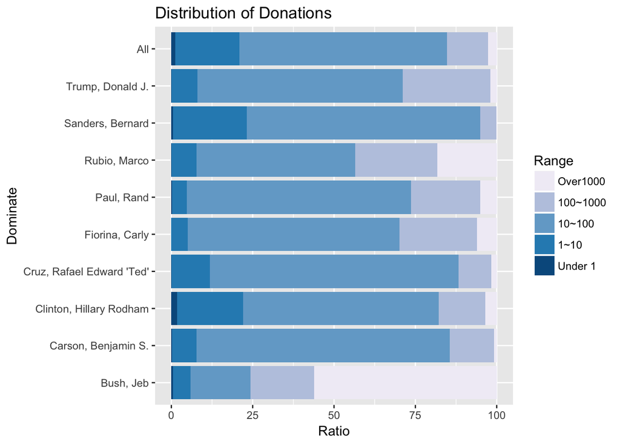

结论：总体来看捐款金额几乎都集中在1000美元之下，大部分捐款不超过100美元。希拉里获得的少于1美元及超过1000美元的比例都高于均值；桑德斯获得超过100美元捐款的比例明显少于其他候选人；Jeb.Bush获得的捐款中有一半都超过了1000美元，在所有候选人中一枝独秀。

##### 图像三

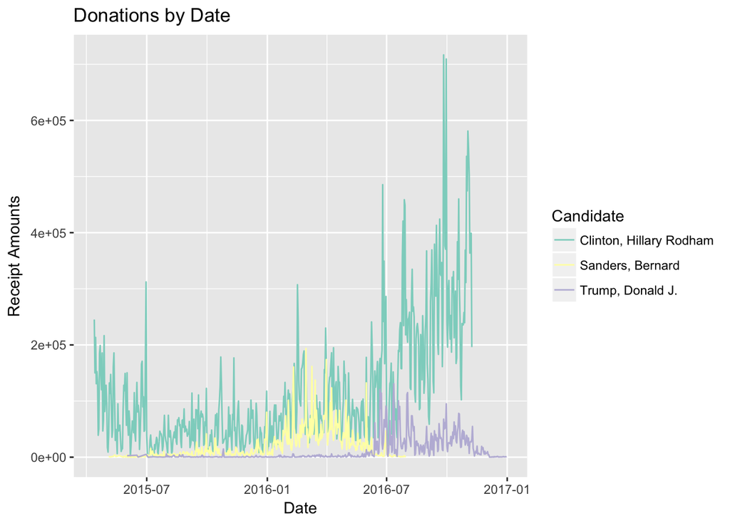

### 反思

- 数据集选择了一个倾向过于明显的州，很多问题比如职业对党派的倾向性无法看出来大的趋势，应该选择一个摇摆州；
- 未来有时间的话，还是应该使用全国数据，可以进一步分析捐款情况和最后竞选结果之间的关系；
- 数据分析缺乏完整的思路，建模的思维几乎是缺失的，在项目整个过程中调整、反复了太多次，需要多加训练；
- 收获是擅用stackoverflow解决了各式各样的小问题。